# Visualize Ridge and Lasso Regression

FRK

27 July, 2021

## With One Predictor

### Motivation

Ridge and Lasso regression are very important concepts in machine learning and variable selection in case of big data in the fields of biostatistics, genomics, bioinformatics etc.

This illustration of mine is motivated from [Josh Starmer](https://www.youtube.com/user/joshstarmer)’s [video](https://www.youtube.com/watch?v=Xm2C_gTAl8c&ab_channel=StatQuestwithJoshStarmer) about ridge and lasso regression. I try to recreate the figures on my own to understand the concepts even better.

### Packages

```r
require(dplyr)
require(ggplot2)
```

### Data for Regression

We generate simple data using the formula

$$E[Y|X] = \beta_1 \times X$$
We are ignoring intercept $\beta_o$ for this demonstration. We use $\epsilon ~ N(0,1)$ errors.

```r
x <- 1:100
y <- 1 * x + rnorm(100, 0, 1)
```

### Ridge SSR

We create a function, that calculates *Sum of Squared Residuals* with a *L2 Norm*. That is

$$\sum[(y_i - (\beta_1 \times X_i))^2] + \lambda \times \beta_1^2$$

```r
### Sum of Squared Residuals with L2 Norm Formula
ssr_ridge <- function(beta_1, Lam){
  sum((y - (beta_1*x))^2) + (Lam*(beta_1^2))
}
```

### Lasso SSR

We create a function, that calculates *Sum of Squared Residuals* with a *L1 Norm*. That is

$$\sum[(y_i - (\beta_1 \times X_i))^2] + \lambda \times |\beta_1|$$

```r
### Sum of Squared Residuals with L1 Norm Formula
ssr_lasso <- function(beta_1, Lam){
  sum((y - (beta_1*x))^2) + (Lam*abs(beta_1))
}
```

### Generate $\beta_1$ and $\lambda$ Value grid for Graphing

```r
### Beta_1 values for graph
b1 <- ((-2000:2000) / 1000)

### Lambda Values
lam <- c(0, 50000, 100000, 200000, 300000, 400000, 500000, 600000, 1000000, 5000000, 50000000)

### Combination of Beta_1 and Lambda Values
B1 <- rep(b1, times = length(lam))
L  <- rep(lam, each = length(b1))
d <- data.frame(B1, L)
head(d)
```

```
##       B1 L
## 1 -2.000 0
## 2 -1.999 0
## 3 -1.998 0
## 4 -1.997 0
## 5 -1.996 0
## 6 -1.995 0
```

### Calculate Ridge and Lasso Sum of Square for each combination of $\beta_1$ and $\lambda$

Next we mutate the ridge and lasso formula for each row of the dataframe *d*. These are the *Sum of Squared Residuals with Norms and penalty*.

```r
d <- d %>%
  group_by(B1, L) %>%
  mutate(val_ridge = ssr_ridge(B1, L),
         val_lasso = ssr_lasso(B1, L)) %>%
  ungroup()
```

### Visualize Ridge

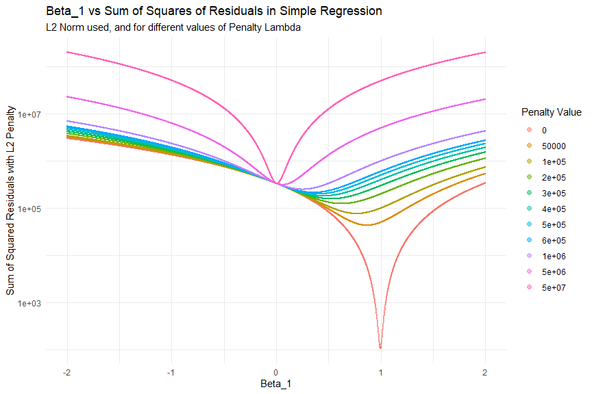

```r
d %>%
  ggplot(aes(B1, val_ridge, color = as.factor(L))) +
  geom_point(alpha = 0.5, size = 0.3) +
  theme_minimal() +
  scale_y_log10() +
  labs(title = "Beta_1 vs Sum of Squares of Residuals in Simple Regression",
       subtitle = "L2 Norm used, and for different values of Penalty Lambda",
       x = "Beta_1",
       y = "Sum of Squared Residuals with L2 Penalty",
       color = "Penalty Value") +
  guides(color = guide_legend(override.aes = list(size = 2)))
```

### Visualize Lasso

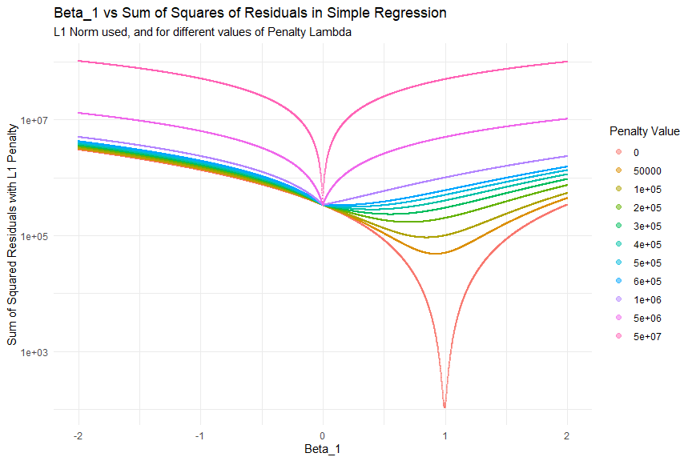

```r
d %>%
  ggplot(aes(B1, val_lasso, color = as.factor(L))) +
  geom_point(alpha = 0.5, size = 0.3) +
  theme_minimal() +
  scale_y_log10() +
  labs(title = "Beta_1 vs Sum of Squares of Residuals in Simple Regression",
       subtitle = "L1 Norm used, and for different values of Penalty Lambda",
       x = "Beta_1",
       y = "Sum of Squared Residuals with L1 Penalty",
       color = "Penalty Value") +
  guides(color = guide_legend(override.aes = list(size = 2)))
```

From both plots we can see that the **SSR** reaches it’s minimum at a $\beta_1$ value of very close to zero, in case of ridge penalty.

And **SSR** reaches it’s minimum at a $\beta_1$ value of exactly zero, in case of lasso penalty.

### Check at which value of $\beta_1$ SSR Achieves Minimum

```r
### Find the Value of Beta_1, WHen Lambda is Maximum, and SSR_Ridge Minimum
d %>%
  filter(L == max(L)) %>%
  filter(val_ridge == min(val_ridge))
```

```
## # A tibble: 1 x 4
##      B1        L val_ridge val_lasso
##   <dbl>    <dbl>     <dbl>     <dbl>
## 1 0.007 50000000   333862.   681412.
```

```r
### Find the Value of Beta_1, WHen Lambda is Maximum, and SSR_Lasso Minimum
d %>%
  filter(L == max(L)) %>%
  filter(val_lasso == min(val_lasso))
```

```
## # A tibble: 1 x 4
##      B1        L val_ridge val_lasso
##   <dbl>    <dbl>     <dbl>     <dbl>
## 1     0 50000000   336116.   336116.
```

### Comment

As we can see, *Lasso* does pushes the value of parameter $\beta_1$ to **exactly zero**. Whereas *Ridge* pushes value of parameter $\beta_1$ **close to zero**.

## With Two Predictors

### Data for Regression

We generate simple data using the formula

$$E[Y|X] = \beta_1 \times X_1 + \beta_2 \times X_2$$
We are ignoring intercept $\beta_o$ for this demonstration. We use $\epsilon ~ N(0,1)$ errors.

```r
x1 <- 1:100
x2 <- (1:100) / 10
y <- 1 * x1 + + 2 * x2 + rnorm(100, 0, 1)
```

### Ridge SSR

We create a function, that calculates *Sum of Squared Residuals* with a *L2 Norm*. That is

$$\sum[(y_i - (\beta_1 \times X_i))^2] + \lambda \times ( \beta_1^2 + \beta_2^2)$$

```r
### Sum of Squared Residuals with L2 Norm Formula
ssr_ridge <- function(beta_1, beta_2, Lam){
  sum((y - (beta_1*x1 + beta_2*x2))^2) + (Lam*(beta_1^2 + beta_2^2))
}
```

### Lasso SSR

We create a function, that calculates *Sum of Squared Residuals* with a *L1 Norm*. That is

$$\sum[(y_i - (\beta_1 \times X_i))^2] + \lambda \times (|\beta_1| + |\beta_2|)$$

```r
### Sum of Squared Residuals with L1 Norm Formula
ssr_lasso <- function(beta_1, beta_2, Lam){
  sum((y - (beta_1*x1 + beta_2*x2))^2) + (Lam*(abs(beta_1) + abs(beta_2)))
}
```

### Generate $\beta_1$, $\beta_2$ & $\lambda$ Value grid for Graphing

```r
### Beta_1 Beta_2 values for graph
b1 <- (-2000:2000) / 1000
b2 <- (-1000:3000) / 1000

### Lambda Values
lam <- c(0, 50000, 100000, 200000, 300000, 400000, 500000, 600000, 1000000, 5000000, 50000000)

### Combination of Beta_1 and Lambda Values
B1 <- rep(b1, times = length(lam))
B2 <- rep(b2, times = length(lam))
L  <- rep(lam, each = length(b1))
d <- data.frame(B1, B2, L)
head(d)
```

```
##       B1     B2 L
## 1 -2.000 -1.000 0
## 2 -1.999 -0.999 0
## 3 -1.998 -0.998 0
## 4 -1.997 -0.997 0
## 5 -1.996 -0.996 0
## 6 -1.995 -0.995 0
```

### Calculate Ridge and Lasso Sum of Square for each combination of $\beta_1$, $\beta_2$ & $\lambda$

Next we mutate the ridge and lasso formula for each row of the dataframe *d*. These are the *Sum of Squared Residuals with Norms and penalty*.

```r
d <- d %>%
  group_by(B1, B2, L) %>%
  mutate(val_ridge = ssr_ridge(B1, B2, L),
         val_lasso = ssr_lasso(B1, B2, L)) %>%
  ungroup()
```

### Visualize Ridge for $\beta_2$

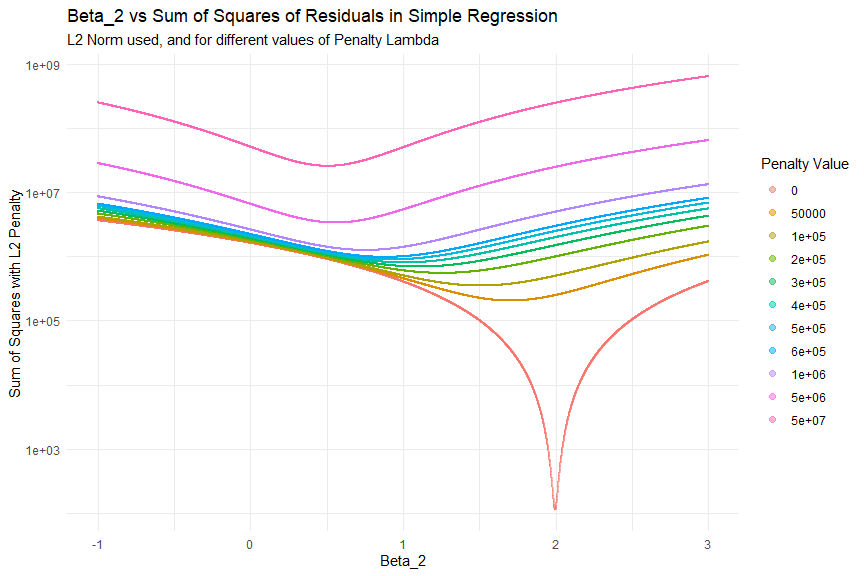

```r
### Visualize Ridge for Beta_2
d %>%
  ggplot(aes(B2, val_ridge, color = as.factor(L))) +
  geom_point(alpha = 0.5, size = 0.3) +
  theme_minimal() +
  scale_y_log10() +
  labs(title = "Beta_2 vs Sum of Squares of Residuals in Simple Regression",
       subtitle = "L2 Norm used, and for different values of Penalty Lambda",
       x = "Beta_2",
       y = "Sum of Squares with L2 Penalty",
       color = "Penalty Value") +
  guides(color = guide_legend(override.aes = list(size = 2)))
```

### Visualize Lasso for $\beta_2$

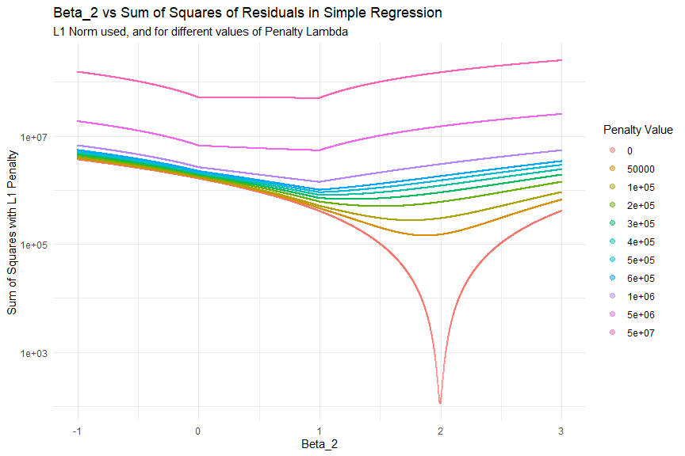

```r
d %>%
  ggplot(aes(B2, val_lasso, color = as.factor(L))) +
  geom_point(alpha = 0.5, size = 0.3) +
  theme_minimal() +
  scale_y_log10() +
  labs(title = "Beta_2 vs Sum of Squares of Residuals in Simple Regression",
       subtitle = "L1 Norm used, and for different values of Penalty Lambda",
       x = "Beta_2",
       y = "Sum of Squares with L1 Penalty",
       color = "Penalty Value") +
  guides(color = guide_legend(override.aes = list(size = 2)))
```

### Check at which value of $\beta_2$ SSR Achieves Minimum

```r
### Find the Value of Beta_2, WHen Lambda is Maximum, and SSR_Ridge Minimum
d %>%
  select(-B1) %>%
  filter(L == max(L)) %>%
  filter(val_ridge == min(val_ridge))
```

```
## # A tibble: 1 x 4
##      B2        L val_ridge val_lasso
##   <dbl>    <dbl>     <dbl>     <dbl>
## 1 0.506 50000000 25913615. 50910015.
```

```r
### Find the Value of Beta_2, WHen Lambda is Maximum, and SSR_Lasso Minimum
d %>%
  select(-B1) %>%
  filter(L == max(L)) %>%
  filter(val_lasso == min(val_lasso))
```

```
## # A tibble: 1 x 4
##      B2        L val_ridge val_lasso
##   <dbl>    <dbl>     <dbl>     <dbl>
## 1     1 50000000 50406906. 50406906.
```

### Comment

As we can see, *Lasso* & *Ridge* pushes value of parameter $\beta_2$ **close to zero**, but not as closely as they push $\beta_1$. So larger coefficients are shrunk but they don’t get close to zero as the smaller coefficients get.